# Risk Factor Analysis

## Outcome Variable

**Outcome Variable:** wasted

## Predictor Variables

**Intervention Variable:** feducyrs

**Adjustment Set:**

unadjusted

## Stratifying Variables

The analysis was stratified on these variable(s):

- agecat
- studyid
- country

## Data Summary

| agecat | studyid | country | feducyrs | wasted | n_cell | n |
| --- | --- | --- | --- | --- | --- | --- |
| Birth | ki0047075b-MAL-ED | BANGLADESH | Low | 0 | 26 | 134 |
| Birth | ki0047075b-MAL-ED | BANGLADESH | Low | 1 | 9 | 134 |
| Birth | ki0047075b-MAL-ED | BANGLADESH | Medium | 0 | 43 | 134 |
| Birth | ki0047075b-MAL-ED | BANGLADESH | Medium | 1 | 7 | 134 |
| Birth | ki0047075b-MAL-ED | BANGLADESH | High | 0 | 44 | 134 |
| Birth | ki0047075b-MAL-ED | BANGLADESH | High | 1 | 5 | 134 |
| Birth | ki0047075b-MAL-ED | INDIA | Low | 0 | 42 | 121 |
| Birth | ki0047075b-MAL-ED | INDIA | Low | 1 | 6 | 121 |
| Birth | ki0047075b-MAL-ED | INDIA | Medium | 0 | 29 | 121 |
| Birth | ki0047075b-MAL-ED | INDIA | Medium | 1 | 6 | 121 |
| Birth | ki0047075b-MAL-ED | INDIA | High | 0 | 34 | 121 |
| Birth | ki0047075b-MAL-ED | INDIA | High | 1 | 4 | 121 |
| Birth | ki0047075b-MAL-ED | NEPAL | Low | 0 | 17 | 64 |
| Birth | ki0047075b-MAL-ED | NEPAL | Low | 1 | 1 | 64 |
| Birth | ki0047075b-MAL-ED | NEPAL | Medium | 0 | 19 | 64 |
| Birth | ki0047075b-MAL-ED | NEPAL | Medium | 1 | 0 | 64 |
| Birth | ki0047075b-MAL-ED | NEPAL | High | 0 | 24 | 64 |
| Birth | ki0047075b-MAL-ED | NEPAL | High | 1 | 3 | 64 |
| Birth | ki0047075b-MAL-ED | PERU | Low | 0 | 62 | 230 |
| Birth | ki0047075b-MAL-ED | PERU | Low | 1 | 1 | 230 |
| Birth | ki0047075b-MAL-ED | PERU | Medium | 0 | 53 | 230 |
| Birth | ki0047075b-MAL-ED | PERU | Medium | 1 | 2 | 230 |
| Birth | ki0047075b-MAL-ED | PERU | High | 0 | 111 | 230 |
| Birth | ki0047075b-MAL-ED | PERU | High | 1 | 1 | 230 |
| Birth | ki0047075b-MAL-ED | SOUTH AFRICA | Low | 0 | 29 | 91 |
| Birth | ki0047075b-MAL-ED | SOUTH AFRICA | Low | 1 | 1 | 91 |
| Birth | ki0047075b-MAL-ED | SOUTH AFRICA | Medium | 0 | 26 | 91 |
| Birth | ki0047075b-MAL-ED | SOUTH AFRICA | Medium | 1 | 0 | 91 |
| Birth | ki0047075b-MAL-ED | SOUTH AFRICA | High | 0 | 34 | 91 |
| Birth | ki0047075b-MAL-ED | SOUTH AFRICA | High | 1 | 1 | 91 |

[output cut: 288 more lines]

The following strata were considered:

- agecat: 24 months, studyid: ki0047075b-MAL-ED, country: BANGLADESH
- agecat: 24 months, studyid: ki0047075b-MAL-ED, country: INDIA
- agecat: 24 months, studyid: ki0047075b-MAL-ED, country: NEPAL
- agecat: 24 months, studyid: ki0047075b-MAL-ED, country: PERU
- agecat: 24 months, studyid: ki0047075b-MAL-ED, country: SOUTH AFRICA
- agecat: 24 months, studyid: ki0047075b-MAL-ED, country: TANZANIA, UNITED REPUBLIC OF
- agecat: 24 months, studyid: ki1017093b-PROVIDE, country: BANGLADESH
- agecat: 24 months, studyid: ki1017093c-NIH-Crypto, country: BANGLADESH
- agecat: 24 months, studyid: ki1066203-TanzaniaChild2, country: TANZANIA, UNITED REPUBLIC OF
- agecat: 24 months, studyid: ki1113344-GMS-Nepal, country: NEPAL
- agecat: 24 months, studyid: ki1119695-PROBIT, country: BELARUS
- agecat: 24 months, studyid: ki1126311-ZVITAMBO, country: ZIMBABWE
- agecat: 24 months, studyid: ki1135781-COHORTS, country: GUATEMALA
- agecat: 24 months, studyid: ki1135781-COHORTS, country: INDIA
- agecat: 24 months, studyid: ki1135781-COHORTS, country: PHILIPPINES
- agecat: 24 months, studyid: ki1148112-LCNI-5, country: MALAWI
- agecat: 24 months, studyid: kiGH5241-JiVitA-3, country: BANGLADESH
- agecat: 24 months, studyid: kiGH5241-JiVitA-4, country: BANGLADESH
- agecat: 6 months, studyid: ki0047075b-MAL-ED, country: BANGLADESH
- agecat: 6 months, studyid: ki0047075b-MAL-ED, country: INDIA
- agecat: 6 months, studyid: ki0047075b-MAL-ED, country: NEPAL
- agecat: 6 months, studyid: ki0047075b-MAL-ED, country: PERU
- agecat: 6 months, studyid: ki0047075b-MAL-ED, country: SOUTH AFRICA
- agecat: 6 months, studyid: ki0047075b-MAL-ED, country: TANZANIA, UNITED REPUBLIC OF
- agecat: 6 months, studyid: ki1000304b-SAS-CompFeed, country: INDIA
- agecat: 6 months, studyid: ki1000304b-SAS-FoodSuppl, country: INDIA
- agecat: 6 months, studyid: ki1017093b-PROVIDE, country: BANGLADESH
- agecat: 6 months, studyid: ki1017093c-NIH-Crypto, country: BANGLADESH
- agecat: 6 months, studyid: ki1066203-TanzaniaChild2, country: TANZANIA, UNITED REPUBLIC OF
- agecat: 6 months, studyid: ki1113344-GMS-Nepal, country: NEPAL
- agecat: 6 months, studyid: ki1119695-PROBIT, country: BELARUS
- agecat: 6 months, studyid: ki1126311-ZVITAMBO, country: ZIMBABWE
- agecat: 6 months, studyid: ki1135781-COHORTS, country: GUATEMALA
- agecat: 6 months, studyid: ki1135781-COHORTS, country: INDIA
- agecat: 6 months, studyid: ki1135781-COHORTS, country: PHILIPPINES
- agecat: 6 months, studyid: ki1148112-LCNI-5, country: MALAWI
- agecat: 6 months, studyid: kiGH5241-JiVitA-3, country: BANGLADESH
- agecat: 6 months, studyid: kiGH5241-JiVitA-4, country: BANGLADESH
- agecat: Birth, studyid: ki0047075b-MAL-ED, country: BANGLADESH
- agecat: Birth, studyid: ki0047075b-MAL-ED, country: INDIA
- agecat: Birth, studyid: ki0047075b-MAL-ED, country: NEPAL
- agecat: Birth, studyid: ki0047075b-MAL-ED, country: PERU
- agecat: Birth, studyid: ki0047075b-MAL-ED, country: SOUTH AFRICA
- agecat: Birth, studyid: ki0047075b-MAL-ED, country: TANZANIA, UNITED REPUBLIC OF
- agecat: Birth, studyid: ki1000304b-SAS-CompFeed, country: INDIA
- agecat: Birth, studyid: ki1017093c-NIH-Crypto, country: BANGLADESH
- agecat: Birth, studyid: ki1119695-PROBIT, country: BELARUS
- agecat: Birth, studyid: ki1126311-ZVITAMBO, country: ZIMBABWE
- agecat: Birth, studyid: ki1135781-COHORTS, country: GUATEMALA
- agecat: Birth, studyid: ki1135781-COHORTS, country: INDIA
- agecat: Birth, studyid: ki1135781-COHORTS, country: PHILIPPINES
- agecat: Birth, studyid: kiGH5241-JiVitA-3, country: BANGLADESH
- agecat: Birth, studyid: kiGH5241-JiVitA-4, country: BANGLADESH

### Dropped Strata

Some strata were dropped due to rare outcomes:

- agecat: Birth, studyid: ki0047075b-MAL-ED, country: INDIA
- agecat: Birth, studyid: ki0047075b-MAL-ED, country: NEPAL
- agecat: Birth, studyid: ki0047075b-MAL-ED, country: PERU
- agecat: Birth, studyid: ki0047075b-MAL-ED, country: SOUTH AFRICA
- agecat: Birth, studyid: ki0047075b-MAL-ED, country: TANZANIA, UNITED REPUBLIC OF
- agecat: Birth, studyid: ki1000304b-SAS-CompFeed, country: INDIA
- agecat: Birth, studyid: ki1017093c-NIH-Crypto, country: BANGLADESH
- agecat: Birth, studyid: kiGH5241-JiVitA-4, country: BANGLADESH
- agecat: 6 months, studyid: ki0047075b-MAL-ED, country: BANGLADESH
- agecat: 6 months, studyid: ki0047075b-MAL-ED, country: INDIA
- agecat: 6 months, studyid: ki0047075b-MAL-ED, country: NEPAL
- agecat: 6 months, studyid: ki0047075b-MAL-ED, country: PERU
- agecat: 6 months, studyid: ki0047075b-MAL-ED, country: SOUTH AFRICA
- agecat: 6 months, studyid: ki0047075b-MAL-ED, country: TANZANIA, UNITED REPUBLIC OF
- agecat: 6 months, studyid: ki1148112-LCNI-5, country: MALAWI
- agecat: 24 months, studyid: ki0047075b-MAL-ED, country: BANGLADESH
- agecat: 24 months, studyid: ki0047075b-MAL-ED, country: INDIA
- agecat: 24 months, studyid: ki0047075b-MAL-ED, country: NEPAL
- agecat: 24 months, studyid: ki0047075b-MAL-ED, country: PERU
- agecat: 24 months, studyid: ki0047075b-MAL-ED, country: SOUTH AFRICA
- agecat: 24 months, studyid: ki0047075b-MAL-ED, country: TANZANIA, UNITED REPUBLIC OF
- agecat: 24 months, studyid: ki1066203-TanzaniaChild2, country: TANZANIA, UNITED REPUBLIC OF
- agecat: 24 months, studyid: ki1126311-ZVITAMBO, country: ZIMBABWE
- agecat: 24 months, studyid: ki1148112-LCNI-5, country: MALAWI

## Methods Detail

We’re interested in the causal parameters $E[Y_a]$ for all values of $a \in \mathcal{A}$. These parameters represent the mean outcome if, possibly contrary to fact, we intervened to set all units to have $A=a$. Under the randomization and positivity assumptions, these are identified by the statistical parameters $\psi_a=E_W[E_{Y|A,W}(Y|A=a,W)]$. In addition, we’re interested in the mean of $Y$, $E[Y]$ under no intervention (the observed mean). We will estimate these parameters by using SuperLearner to fit the relevant likelihood factors – $E_{Y|A,W}(Y|A=a,W)$ and $p(A=a|W)$, and then updating our likelihood fit using a joint TMLE.

For unadjusted analyses ($W=\{\}$), initial likelihoods were estimated using Lrnr_glm to estimate the simple $E(Y|A)$ and Lrnr_mean to estimate $p(A)$. For adjusted analyses, a small library containing Lrnr_glmnet, Lrnr_xgboost, and Lrnr_mean was used.

Having estimated these parameters, we will then use the delta method to estimate relative risks and attributable risks relative to a prespecified baseline level of $A$.

# Results Detail

## Results Plots

[figure not shown]

[figure not shown]

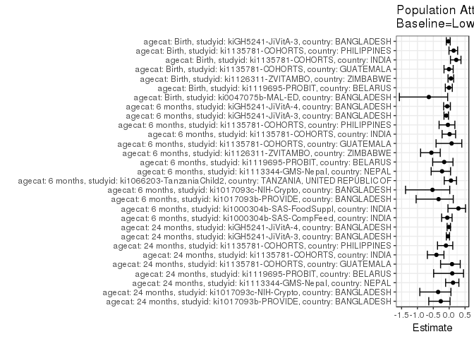

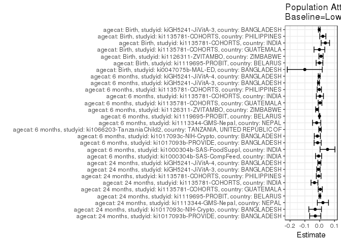

## Results Table

### Parameter: TSM

| agecat | studyid | country | intervention_level | baseline_level | estimate | ci_lower | ci_upper |
| --- | --- | --- | --- | --- | --- | --- | --- |
| Birth | ki0047075b-MAL-ED | BANGLADESH | Low | NA | 0.2571429 | 0.1118044 | 0.4024813 |
| Birth | ki0047075b-MAL-ED | BANGLADESH | Medium | NA | 0.1400000 | 0.0434610 | 0.2365390 |
| Birth | ki0047075b-MAL-ED | BANGLADESH | High | NA | 0.1020408 | 0.0169678 | 0.1871138 |
| Birth | ki1119695-PROBIT | BELARUS | Low | NA | 0.2091046 | 0.1355762 | 0.2826331 |
| Birth | ki1119695-PROBIT | BELARUS | Medium | NA | 0.2113051 | 0.1473777 | 0.2752324 |
| Birth | ki1119695-PROBIT | BELARUS | High | NA | 0.1951220 | 0.1265377 | 0.2637062 |
| Birth | ki1126311-ZVITAMBO | ZIMBABWE | Low | NA | 0.1488038 | 0.1335453 | 0.1640624 |
| Birth | ki1126311-ZVITAMBO | ZIMBABWE | Medium | NA | 0.1585493 | 0.1512303 | 0.1658683 |
| Birth | ki1126311-ZVITAMBO | ZIMBABWE | High | NA | 0.1695842 | 0.1452548 | 0.1939137 |
| Birth | ki1135781-COHORTS | GUATEMALA | Low | NA | 0.2540193 | 0.2056057 | 0.3024329 |
| Birth | ki1135781-COHORTS | GUATEMALA | Medium | NA | 0.2250923 | 0.1753333 | 0.2748512 |
| Birth | ki1135781-COHORTS | GUATEMALA | High | NA | 0.3014706 | 0.2242921 | 0.3786490 |
| Birth | ki1135781-COHORTS | INDIA | Low | NA | 0.1328502 | 0.1001430 | 0.1655575 |
| Birth | ki1135781-COHORTS | INDIA | Medium | NA | 0.2081081 | 0.1667279 | 0.2494883 |
| Birth | ki1135781-COHORTS | INDIA | High | NA | 0.1755424 | 0.1424150 | 0.2086698 |
| Birth | ki1135781-COHORTS | PHILIPPINES | Low | NA | 0.1293661 | 0.1057033 | 0.1530289 |
| Birth | ki1135781-COHORTS | PHILIPPINES | Medium | NA | 0.1404787 | 0.1185052 | 0.1624522 |
| Birth | ki1135781-COHORTS | PHILIPPINES | High | NA | 0.1770624 | 0.1533278 | 0.2007969 |
| Birth | kiGH5241-JiVitA-3 | BANGLADESH | Low | NA | 0.0982772 | 0.0902736 | 0.1062807 |
| Birth | kiGH5241-JiVitA-3 | BANGLADESH | Medium | NA | 0.0952748 | 0.0864141 | 0.1041356 |
| Birth | kiGH5241-JiVitA-3 | BANGLADESH | High | NA | 0.0909091 | 0.0800160 | 0.1018022 |
| 6 months | ki1000304b-SAS-CompFeed | INDIA | Low | NA | 0.1313869 | 0.0961526 | 0.1666212 |
| 6 months | ki1000304b-SAS-CompFeed | INDIA | Medium | NA | 0.1267281 | 0.0945698 | 0.1588864 |
| 6 months | ki1000304b-SAS-CompFeed | INDIA | High | NA | 0.1088825 | 0.0818315 | 0.1359336 |
| 6 months | ki1000304b-SAS-FoodSuppl | INDIA | Low | NA | 0.1287879 | 0.0715699 | 0.1860059 |
| 6 months | ki1000304b-SAS-FoodSuppl | INDIA | Medium | NA | 0.2244898 | 0.1569509 | 0.2920286 |
| 6 months | ki1000304b-SAS-FoodSuppl | INDIA | High | NA | 0.1881188 | 0.1118017 | 0.2644359 |
| 6 months | ki1017093b-PROVIDE | BANGLADESH | Low | NA | 0.0550000 | 0.0233769 | 0.0866231 |
| 6 months | ki1017093b-PROVIDE | BANGLADESH | Medium | NA | 0.0279330 | 0.0037727 | 0.0520932 |
| 6 months | ki1017093b-PROVIDE | BANGLADESH | High | NA | 0.0394089 | 0.0126209 | 0.0661968 |

[output cut: 57 more lines]

### Parameter: E(Y)

| agecat | studyid | country | intervention_level | baseline_level | estimate | ci_lower | ci_upper |
| --- | --- | --- | --- | --- | --- | --- | --- |
| Birth | ki0047075b-MAL-ED | BANGLADESH | NA | NA | 0.1567164 | 0.0949338 | 0.2184990 |
| Birth | ki1119695-PROBIT | BELARUS | NA | NA | 0.2079497 | 0.1424160 | 0.2734834 |
| Birth | ki1126311-ZVITAMBO | ZIMBABWE | NA | NA | 0.1577315 | 0.1513599 | 0.1641031 |
| Birth | ki1135781-COHORTS | GUATEMALA | NA | NA | 0.2520891 | 0.2203065 | 0.2838718 |
| Birth | ki1135781-COHORTS | INDIA | NA | NA | 0.1711851 | 0.1506302 | 0.1917400 |
| Birth | ki1135781-COHORTS | PHILIPPINES | NA | NA | 0.1506598 | 0.1372339 | 0.1640858 |
| Birth | kiGH5241-JiVitA-3 | BANGLADESH | NA | NA | 0.0956568 | 0.0903208 | 0.1009928 |
| 6 months | ki1000304b-SAS-CompFeed | INDIA | NA | NA | 0.1239669 | 0.0988748 | 0.1490591 |
| 6 months | ki1000304b-SAS-FoodSuppl | INDIA | NA | NA | 0.1815789 | 0.1427684 | 0.2203895 |
| 6 months | ki1017093b-PROVIDE | BANGLADESH | NA | NA | 0.0412371 | 0.0250690 | 0.0574052 |
| 6 months | ki1017093c-NIH-Crypto | BANGLADESH | NA | NA | 0.0293706 | 0.0169860 | 0.0417552 |
| 6 months | ki1066203-TanzaniaChild2 | TANZANIA, UNITED REPUBLIC OF | NA | NA | 0.0431334 | 0.0342652 | 0.0520016 |
| 6 months | ki1113344-GMS-Nepal | NEPAL | NA | NA | 0.0907473 | 0.0669775 | 0.1145172 |
| 6 months | ki1119695-PROBIT | BELARUS | NA | NA | 0.0084172 | 0.0066782 | 0.0101561 |
| 6 months | ki1126311-ZVITAMBO | ZIMBABWE | NA | NA | 0.0316235 | 0.0277962 | 0.0354508 |
| 6 months | ki1135781-COHORTS | GUATEMALA | NA | NA | 0.0320442 | 0.0205636 | 0.0435248 |
| 6 months | ki1135781-COHORTS | INDIA | NA | NA | 0.1148014 | 0.0980067 | 0.1315962 |
| 6 months | ki1135781-COHORTS | PHILIPPINES | NA | NA | 0.0581577 | 0.0490934 | 0.0672220 |
| 6 months | kiGH5241-JiVitA-3 | BANGLADESH | NA | NA | 0.0845872 | 0.0796525 | 0.0895218 |
| 6 months | kiGH5241-JiVitA-4 | BANGLADESH | NA | NA | 0.0556693 | 0.0447722 | 0.0665664 |
| 24 months | ki1017093b-PROVIDE | BANGLADESH | NA | NA | 0.1124567 | 0.0866788 | 0.1382347 |
| 24 months | ki1017093c-NIH-Crypto | BANGLADESH | NA | NA | 0.0875486 | 0.0630907 | 0.1120065 |
| 24 months | ki1113344-GMS-Nepal | NEPAL | NA | NA | 0.1810865 | 0.1471967 | 0.2149763 |
| 24 months | ki1119695-PROBIT | BELARUS | NA | NA | 0.0111630 | 0.0050745 | 0.0172515 |
| 24 months | ki1135781-COHORTS | GUATEMALA | NA | NA | 0.0449102 | 0.0320802 | 0.0577401 |
| 24 months | ki1135781-COHORTS | INDIA | NA | NA | 0.0875912 | 0.0726161 | 0.1025664 |
| 24 months | ki1135781-COHORTS | PHILIPPINES | NA | NA | 0.0668392 | 0.0566723 | 0.0770060 |
| 24 months | kiGH5241-JiVitA-3 | BANGLADESH | NA | NA | 0.2190286 | 0.2088944 | 0.2291627 |
| 24 months | kiGH5241-JiVitA-4 | BANGLADESH | NA | NA | 0.1958763 | 0.1777261 | 0.2140265 |

### Parameter: RR

| agecat | studyid | country | intervention_level | baseline_level | estimate | ci_lower | ci_upper |
| --- | --- | --- | --- | --- | --- | --- | --- |
| Birth | ki0047075b-MAL-ED | BANGLADESH | Low | Low | 1.0000000 | 1.0000000 | 1.0000000 |
| Birth | ki0047075b-MAL-ED | BANGLADESH | Medium | Low | 0.5444444 | 0.2232211 | 1.3279198 |
| Birth | ki0047075b-MAL-ED | BANGLADESH | High | Low | 0.3968254 | 0.1449304 | 1.0865246 |
| Birth | ki1119695-PROBIT | BELARUS | Low | Low | 1.0000000 | 1.0000000 | 1.0000000 |
| Birth | ki1119695-PROBIT | BELARUS | Medium | Low | 1.0105231 | 0.8423644 | 1.2122507 |
| Birth | ki1119695-PROBIT | BELARUS | High | Low | 0.9331306 | 0.7538436 | 1.1550575 |
| Birth | ki1126311-ZVITAMBO | ZIMBABWE | Low | Low | 1.0000000 | 1.0000000 | 1.0000000 |
| Birth | ki1126311-ZVITAMBO | ZIMBABWE | Medium | Low | 1.0654922 | 0.9521656 | 1.1923070 |
| Birth | ki1126311-ZVITAMBO | ZIMBABWE | High | Low | 1.1396497 | 0.9554023 | 1.3594288 |
| Birth | ki1135781-COHORTS | GUATEMALA | Low | Low | 1.0000000 | 1.0000000 | 1.0000000 |
| Birth | ki1135781-COHORTS | GUATEMALA | Medium | Low | 0.8861227 | 0.6618097 | 1.1864640 |
| Birth | ki1135781-COHORTS | GUATEMALA | High | Low | 1.1868019 | 0.8625180 | 1.6330081 |
| Birth | ki1135781-COHORTS | INDIA | Low | Low | 1.0000000 | 1.0000000 | 1.0000000 |
| Birth | ki1135781-COHORTS | INDIA | Medium | Low | 1.5664865 | 1.1415307 | 2.1496398 |
| Birth | ki1135781-COHORTS | INDIA | High | Low | 1.3213556 | 0.9689474 | 1.8019353 |
| Birth | ki1135781-COHORTS | PHILIPPINES | Low | Low | 1.0000000 | 1.0000000 | 1.0000000 |
| Birth | ki1135781-COHORTS | PHILIPPINES | Medium | Low | 1.0859001 | 0.8536234 | 1.3813809 |
| Birth | ki1135781-COHORTS | PHILIPPINES | High | Low | 1.3686922 | 1.0909875 | 1.7170849 |
| Birth | kiGH5241-JiVitA-3 | BANGLADESH | Low | Low | 1.0000000 | 1.0000000 | 1.0000000 |
| Birth | kiGH5241-JiVitA-3 | BANGLADESH | Medium | Low | 0.9694505 | 0.8574050 | 1.0961380 |
| Birth | kiGH5241-JiVitA-3 | BANGLADESH | High | Low | 0.9250277 | 0.8015168 | 1.0675713 |
| 6 months | ki1000304b-SAS-CompFeed | INDIA | Low | Low | 1.0000000 | 1.0000000 | 1.0000000 |
| 6 months | ki1000304b-SAS-CompFeed | INDIA | Medium | Low | 0.9645417 | 0.7330005 | 1.2692225 |
| 6 months | ki1000304b-SAS-CompFeed | INDIA | High | Low | 0.8287170 | 0.5886078 | 1.1667731 |
| 6 months | ki1000304b-SAS-FoodSuppl | INDIA | Low | Low | 1.0000000 | 1.0000000 | 1.0000000 |
| 6 months | ki1000304b-SAS-FoodSuppl | INDIA | Medium | Low | 1.7430972 | 1.0192847 | 2.9809023 |
| 6 months | ki1000304b-SAS-FoodSuppl | INDIA | High | Low | 1.4606872 | 0.8003313 | 2.6659050 |
| 6 months | ki1017093b-PROVIDE | BANGLADESH | Low | Low | 1.0000000 | 1.0000000 | 1.0000000 |
| 6 months | ki1017093b-PROVIDE | BANGLADESH | Medium | Low | 0.5078720 | 0.1797603 | 1.4348774 |
| 6 months | ki1017093b-PROVIDE | BANGLADESH | High | Low | 0.7165249 | 0.2941563 | 1.7453574 |

[output cut: 57 more lines]

### Parameter: PAR

| agecat | studyid | country | intervention_level | baseline_level | estimate | ci_lower | ci_upper |
| --- | --- | --- | --- | --- | --- | --- | --- |
| Birth | ki0047075b-MAL-ED | BANGLADESH | Low | NA | -0.1004264 | -0.2183494 | 0.0174965 |
| Birth | ki1119695-PROBIT | BELARUS | Low | NA | -0.0011549 | -0.0239972 | 0.0216873 |
| Birth | ki1126311-ZVITAMBO | ZIMBABWE | Low | NA | 0.0089276 | -0.0050728 | 0.0229280 |
| Birth | ki1135781-COHORTS | GUATEMALA | Low | NA | -0.0019302 | -0.0383105 | 0.0344501 |
| Birth | ki1135781-COHORTS | INDIA | Low | NA | 0.0383349 | 0.0099419 | 0.0667279 |
| Birth | ki1135781-COHORTS | PHILIPPINES | Low | NA | 0.0212937 | 0.0007301 | 0.0418574 |
| Birth | kiGH5241-JiVitA-3 | BANGLADESH | Low | NA | -0.0026204 | -0.0084947 | 0.0032540 |
| 6 months | ki1000304b-SAS-CompFeed | INDIA | Low | NA | -0.0074199 | -0.0279691 | 0.0131293 |
| 6 months | ki1000304b-SAS-FoodSuppl | INDIA | Low | NA | 0.0527911 | 0.0027345 | 0.1028476 |
| 6 months | ki1017093b-PROVIDE | BANGLADESH | Low | NA | -0.0137629 | -0.0377239 | 0.0101981 |
| 6 months | ki1017093c-NIH-Crypto | BANGLADESH | Low | NA | -0.0154724 | -0.0362416 | 0.0052968 |
| 6 months | ki1066203-TanzaniaChild2 | TANZANIA, UNITED REPUBLIC OF | Low | NA | 0.0024679 | -0.0058113 | 0.0107472 |
| 6 months | ki1113344-GMS-Nepal | NEPAL | Low | NA | -0.0203638 | -0.0482299 | 0.0075024 |
| 6 months | ki1119695-PROBIT | BELARUS | Low | NA | -0.0013176 | -0.0040497 | 0.0014144 |
| 6 months | ki1126311-ZVITAMBO | ZIMBABWE | Low | NA | -0.0177327 | -0.0276678 | -0.0077976 |
| 6 months | ki1135781-COHORTS | GUATEMALA | Low | NA | 0.0024875 | -0.0101507 | 0.0151258 |
| 6 months | ki1135781-COHORTS | INDIA | Low | NA | 0.0014681 | -0.0226706 | 0.0256068 |
| 6 months | ki1135781-COHORTS | PHILIPPINES | Low | NA | -0.0023262 | -0.0166512 | 0.0119989 |
| 6 months | kiGH5241-JiVitA-3 | BANGLADESH | Low | NA | -0.0076887 | -0.0136616 | -0.0017158 |
| 6 months | kiGH5241-JiVitA-4 | BANGLADESH | Low | NA | -0.0034856 | -0.0094917 | 0.0025205 |
| 24 months | ki1017093b-PROVIDE | BANGLADESH | Low | NA | -0.0296752 | -0.0673939 | 0.0080435 |
| 24 months | ki1017093c-NIH-Crypto | BANGLADESH | Low | NA | -0.0305069 | -0.0731898 | 0.0121759 |
| 24 months | ki1113344-GMS-Nepal | NEPAL | Low | NA | 0.0219956 | -0.0156470 | 0.0596383 |
| 24 months | ki1119695-PROBIT | BELARUS | Low | NA | 0.0010824 | -0.0042494 | 0.0064142 |
| 24 months | ki1135781-COHORTS | GUATEMALA | Low | NA | 0.0040500 | -0.0096575 | 0.0177575 |
| 24 months | ki1135781-COHORTS | INDIA | Low | NA | -0.0351766 | -0.0585003 | -0.0118530 |
| 24 months | ki1135781-COHORTS | PHILIPPINES | Low | NA | -0.0067539 | -0.0227376 | 0.0092298 |
| 24 months | kiGH5241-JiVitA-3 | BANGLADESH | Low | NA | -0.0082982 | -0.0195690 | 0.0029726 |
| 24 months | kiGH5241-JiVitA-4 | BANGLADESH | Low | NA | -0.0019259 | -0.0124333 | 0.0085815 |

### Parameter: PAF

| agecat | studyid | country | intervention_level | baseline_level | estimate | ci_lower | ci_upper |
| --- | --- | --- | --- | --- | --- | --- | --- |
| Birth | ki0047075b-MAL-ED | BANGLADESH | Low | NA | -0.6408163 | -1.5691781 | -0.0479142 |
| Birth | ki1119695-PROBIT | BELARUS | Low | NA | -0.0055540 | -0.1212535 | 0.0982068 |
| Birth | ki1126311-ZVITAMBO | ZIMBABWE | Low | NA | 0.0566002 | -0.0364495 | 0.1412961 |
| Birth | ki1135781-COHORTS | GUATEMALA | Low | NA | -0.0076566 | -0.1628165 | 0.1267996 |
| Birth | ki1135781-COHORTS | INDIA | Low | NA | 0.2239382 | 0.0408600 | 0.3720708 |
| Birth | ki1135781-COHORTS | PHILIPPINES | Low | NA | 0.1413364 | -0.0061264 | 0.2671864 |
| Birth | kiGH5241-JiVitA-3 | BANGLADESH | Low | NA | -0.0273936 | -0.0906692 | 0.0322111 |
| 6 months | ki1000304b-SAS-CompFeed | INDIA | Low | NA | -0.0598540 | -0.2371872 | 0.0920610 |
| 6 months | ki1000304b-SAS-FoodSuppl | INDIA | Low | NA | 0.2907334 | -0.0390676 | 0.5158553 |
| 6 months | ki1017093b-PROVIDE | BANGLADESH | Low | NA | -0.3337500 | -1.0416461 | 0.1286986 |
| 6 months | ki1017093c-NIH-Crypto | BANGLADESH | Low | NA | -0.5267990 | -1.3752445 | 0.0185788 |
| 6 months | ki1066203-TanzaniaChild2 | TANZANIA, UNITED REPUBLIC OF | Low | NA | 0.0572163 | -0.1552596 | 0.2306136 |
| 6 months | ki1113344-GMS-Nepal | NEPAL | Low | NA | -0.2244009 | -0.5679216 | 0.0438568 |
| 6 months | ki1119695-PROBIT | BELARUS | Low | NA | -0.1565411 | -0.5201954 | 0.1201215 |
| 6 months | ki1126311-ZVITAMBO | ZIMBABWE | Low | NA | -0.5607448 | -0.9006461 | -0.2816296 |
| 6 months | ki1135781-COHORTS | GUATEMALA | Low | NA | 0.0776287 | -0.4131012 | 0.3979420 |
| 6 months | ki1135781-COHORTS | INDIA | Low | NA | 0.0127883 | -0.2215390 | 0.2021646 |
| 6 months | ki1135781-COHORTS | PHILIPPINES | Low | NA | -0.0399978 | -0.3178387 | 0.1792656 |
| 6 months | kiGH5241-JiVitA-3 | BANGLADESH | Low | NA | -0.0908968 | -0.1635409 | -0.0227882 |
| 6 months | kiGH5241-JiVitA-4 | BANGLADESH | Low | NA | -0.0626125 | -0.1740144 | 0.0382185 |
| 24 months | ki1017093b-PROVIDE | BANGLADESH | Low | NA | -0.2638813 | -0.6431510 | 0.0278459 |
| 24 months | ki1017093c-NIH-Crypto | BANGLADESH | Low | NA | -0.3484568 | -0.9253876 | 0.0556002 |
| 24 months | ki1113344-GMS-Nepal | NEPAL | Low | NA | 0.1214646 | -0.1120945 | 0.3059723 |
| 24 months | ki1119695-PROBIT | BELARUS | Low | NA | 0.0969617 | -0.4895867 | 0.4525474 |
| 24 months | ki1135781-COHORTS | GUATEMALA | Low | NA | 0.0901792 | -0.2710851 | 0.3487660 |
| 24 months | ki1135781-COHORTS | INDIA | Low | NA | -0.4015997 | -0.6869502 | -0.1645167 |
| 24 months | ki1135781-COHORTS | PHILIPPINES | Low | NA | -0.1010473 | -0.3676225 | 0.1135674 |
| 24 months | kiGH5241-JiVitA-3 | BANGLADESH | Low | NA | -0.0378865 | -0.0906787 | 0.0123504 |
| 24 months | kiGH5241-JiVitA-4 | BANGLADESH | Low | NA | -0.0098323 | -0.0649425 | 0.0424260 |